# Stability Measures

Download a copy of the vignette to follow along here: stability_measures.Rmd

In this vignette, we will highlight the main stability measure options in the `metasnf` package.

## Data set-up

```r
library(metasnf)

my_dl <- data_list(
    list(cort_t, "cortical_thickness", "neuroimaging", "continuous"),
    list(cort_sa, "cortical_area", "neuroimaging", "continuous"),
    list(subc_v, "subcortical_volume", "neuroimaging", "continuous"),
    list(income, "household_income", "demographics", "continuous"),
    list(pubertal, "pubertal_status", "demographics", "continuous"),
    uid = "unique_id"
)

set.seed(42)
sc <- snf_config(
    my_dl,
    n_solutions = 4,
    max_k = 40
)

sol_df <- batch_snf(my_dl, sc)
```

To begin start calculating resampling-based stability measures, we’ll build subsamples of the data list using the `subsample_dl` function.

```r
my_dl_subsamples <- subsample_dl(
    my_dl,
    n_subsamples = 50,
    subsample_fraction = 0.85
)
```

```r
batch_subsample_results <- batch_snf_subsamples(
    my_dl_subsamples,
    sc,
    verbose = TRUE
)
```

By default, the function returns a one-element list: `cluster_solutions`, which is itself a list of cluster solution data frames corresponding to each of the provided data list subsamples. Setting the parameters `return_sim_mats` and `return_solutions` to `TRUE` will turn the result of the function to a three-element list containing the corresponding solutions data frames and final fused similarity matrices of those cluster solutions, should you require these objects for your own stability calculations.

The function `subsample_pairwise_aris` can then be used to calculate the ARIs between cluster solutions across the subsamples.

```r
pairwise_aris <- subsample_pairwise_aris(
    batch_subsample_results,
    verbose = TRUE
)
```

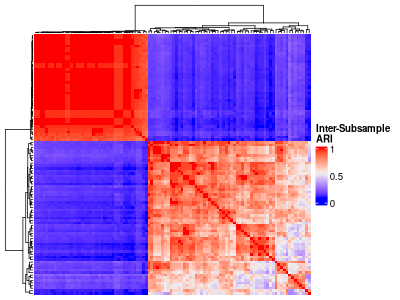

```r
inter_ss_ari_hm <- ComplexHeatmap::Heatmap(
    pairwise_aris$"raw_aris"$"s1",
    heatmap_legend_param = list(
        color_bar = "continuous",
        title = "Inter-Subsample\nARI",
        at = c(0, 0.5, 1)
    ),
    show_column_names = FALSE,
    show_row_names = FALSE
)
```

To calculate information about how often each pair of observations clustered together across the subsamples, we can use the `calculate_coclustering` function:

```r
coclustering_results <- calculate_coclustering(
    batch_subsample_results,
    sol_df,
    verbose = TRUE
)

coclustering_results$"cocluster_summary"
```

[output not shown]

The output of `calculate_coclustering` is a list containing the following components: - `cocluster_dfs`: A list of data frames, one per cluster solution, that shows the number of times that every pair of observations in the original cluster solution occurred in the same subsample, the number of times that every pair clustered together in a subsample, and the corresponding fraction of times that every pair clustered together in a subsample. - `cocluster_ss_mats`: The number of times every pair of observations occurred in the same subsample, formatted as a pairwise matrix. - `cocluster_sc_mats`: The number of times every pair of observations occurred in the same cluster, formatted as a pairwise matrix. - `cocluster_cf_mats`: The fraction of times every pair of observations occurred in the same cluster, formatted as a pairwise matrix. - `cocluster_summary`: Among pairs of observations that clustered together in the original cluster solution, the mean fraction those pairs remained clustered together across the subsample-derived solutions. This information is formatted as a data frame with one row per cluster solution.

The `cocluster_dfs` component can be used to visualize co-clustering across subsamples as a density plot:

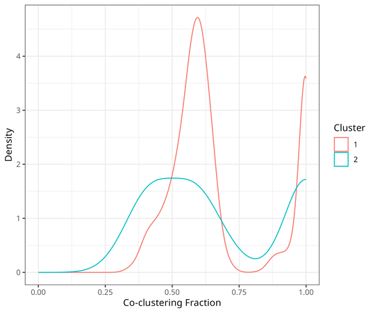

```r
cocluster_dfs <- coclustering_results$"cocluster_dfs"

cocluster_density(cocluster_dfs[[1]])
```

Or as a heatmap:

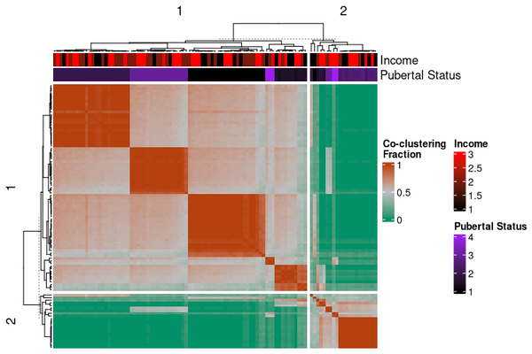

```r
# Fraction of co-clustering between observations, grouped by original
# cluster membership
cocluster_heatmap(
    cocluster_dfs[[1]],
    dl = my_dl,
    top_hm = list(
        "Income" = "household_income",
        "Pubertal Status" = "pubertal_status"
    ),
    annotation_colours = list(
        "Pubertal Status" = colour_scale(
            c(1, 4),
            min_colour = "black",
            max_colour = "purple"
        ),
        "Income" = colour_scale(
            c(0, 4),
            min_colour = "black",
            max_colour = "red"
        )
    )
)
```